# mystatsfunctions

This notebook contains examples of the `OLSE` and `LMoments` modules, available here: https://github.com/njleach/mystatsfunctions

### Import modules

```python
# base libraries
import numpy as np
import scipy as sp
import xarray as xr
import pandas as pd

# plotting libraries
import matplotlib
import matplotlib.pyplot as plt
from mpl_toolkits.axes_grid1.inset_locator import inset_axes
import seaborn as sn
import cartopy
from cartopy import crs
from cartopy.mpl.ticker import LongitudeFormatter, LatitudeFormatter
import cartopy.feature as cfeature

from mystatsfunctions import OLSE,LMoments
```

### Retrieve some example data

In this example I'll be using maximum temperature data from E-OBS. This is available to download here: https://surfobs.climate.copernicus.eu/dataaccess/access_eobs.php. I've pre-processed the daily maximum temperature data using cdo as follows:

`cdo mergetime -yearmax tx_ens_mean_0.1deg_reg_pre1950.nc -yearmax tx_ens_mean_0.1deg_reg_v23.1e.nc txx_ens_mean_0.1deg_reg_v23.1e_pre1950_merge.nc`

Reference:

Cornes, R. C., van der Schrier, G., van den Besselaar, E. J. M., & Jones, P. D. (2018). An Ensemble Version of the E-OBS Temperature and Precipitation Data Sets. Journal of Geophysical Research: Atmospheres, 123(17), 9391–9409. https://doi.org/10.1029/2017JD028200

```python
txx_eobs = xr.open_dataset('/home/leachl/Documents/Datasets/Reanalyses/E-OBS/preproc/txx_ens_mean_0.1deg_reg_v23.1e_pre1950_merge.nc').tx
```

I'll also use the Cowtan-Way global mean surface temperature dataset as a covariate.

Reference:

Cowtan, K., & Way, R. G. (2014). Coverage bias in the HadCRUT4 temperature series and its impact on recent temperature trends. Quarterly Journal of the Royal Meteorological Society, 140(683), 1935–1944. https://doi.org/10.1002/qj.2297

```python
GMST = pd.read_csv('https://www-users.york.ac.uk/~kdc3/papers/coverage2013/had4_krig_annual_v2_0_0.txt',delim_whitespace=True,index_col=0,usecols=[0,1],names=['year','raw'])

## use a lowess smoother to remove the internal variability
import statsmodels.api as sm
lowess = sm.nonparametric.lowess

## I'll use 30-year blocks
GMST['smooth'] = lowess(GMST.raw,GMST.index,frac = 30/GMST.size)[:,1]
```

Let's check the smoothed serise looks reasonable:

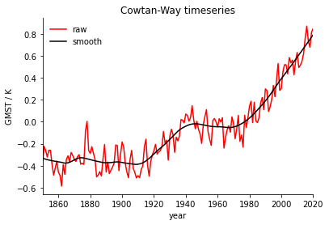

```python
GMST.plot(color=['r','k'])
plt.legend(frameon=False)
plt.xlim(1850,2020)
plt.title('Cowtan-Way timeseries')
plt.ylabel('GMST / K')
sn.despine()
```

## I. Trend in maximum temperatures

In this section I'll use the `OLSE` module to estimate the trend in the hottest day in the year, by regressing the global mean temperature change onto the gridpoint txx timeseries.

```python
## the inputs to OLSE.simple must be numpy arrays
Y = txx_eobs.values
X = GMST.loc[txx_eobs['time.year'].values,'smooth'].values

## mask out gridpoints if there are fewer than 80 years valid data
mask = np.isnan(Y) + (np.isnan(Y).sum(axis=0)>20)
```

This next cell creates the `simple` regression object & fits it to the independent variable.

```python
## initialise simple linear regression object with the dependent variable and mask arrays
SLR = OLSE.simple(Y,mask=mask)

## fit to (broadcasted) X array
SLR.fit(np.broadcast_to(X[:,None,None],Y.shape))
```

And here we demonstrate some of the attributes and methods of the `simple` object.

The `pred()` and confidence/prediction interval, `CI()` and `PI()`, methods are computed on the X array values by default; the intervals are 90 % by default.

```python
## We'll store the outputs in an DataArray for convenience

## model parameters
intercept = xr.zeros_like(txx_eobs.isel(time=-1)).rename('trend')+SLR.b0
slope = xr.zeros_like(txx_eobs.isel(time=-1)).rename('trend')+SLR.b1
slope_err = xr.zeros_like(txx_eobs.isel(time=-1)).rename('trend error')+SLR.err_b1

## model correlation
cor = xr.zeros_like(txx_eobs.isel(time=-1)).rename('correlation')+SLR.cor()

## linear model estimates + confidence intervals
model=xr.zeros_like(txx_eobs).rename('model')+SLR.pred()
CI=xr.zeros_like(txx_eobs).expand_dims({'percentile':[5,95]}).rename('CI')+SLR.CI()
PI=xr.zeros_like(txx_eobs).expand_dims({'percentile':[5,95]}).rename('PI')+SLR.PI()
```

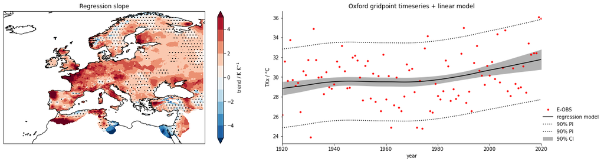

```python
## set the figure layout
fig = plt.figure(figsize=(20,5))
gs = fig.add_gridspec(1,2,wspace=0.1)
map_ax = fig.add_subplot(gs[:,0],projection=crs.PlateCarree())
ts_ax = fig.add_subplot(gs[:,1])

## plot the trend map
p=slope.plot(ax=map_ax,levels=np.linspace(-5,5,11),extend='both',cmap='RdBu_r')
## add in significance stippling (stippling = not significant @ 2-sided 95 % level)
(slope_err*sp.stats.t((~mask).sum(axis=0)).ppf(0.975) > xr.ufuncs.fabs(slope)).plot.contourf(ax=map_ax,alpha=0,levels=[-0.5,0.5,1],hatches=[None,'..'],add_colorbar=False)

p.axes.coastlines('50m')
p.axes.set_title('Regression slope')
p.colorbar.set_label('trend / K K$^{-1}$')

## timeseries plot for Oxford gridpoint
ts_ax.plot(txx_eobs['time.year'].values,txx_eobs.sel(latitude=51.75,longitude=-1.25,method='nearest').values,'r.',label='E-OBS')
ts_ax.plot(model['time.year'].values,model.sel(latitude=51.75,longitude=-1.25,method='nearest').values,'k',label='regression model')
ts_ax.fill_between(model['time.year'].values,*CI.sel(latitude=51.75,longitude=-1.25,method='nearest').values,color='k',alpha=0.3,lw=0,label='90% CI')
ts_ax.plot(model['time.year'].values,PI.sel(latitude=51.75,longitude=-1.25,method='nearest').values.T,color='k',ls=':',label='90% PI')

ts_ax.set_title('Oxford gridpoint timeseries + linear model')
ts_ax.set_ylabel('TXx / \N{DEGREE SIGN}C')
ts_ax.set_xlabel('year')
ts_ax.set_xlim(1920,2020)
ts_ax.legend(frameon=False,loc=(1,0))

sn.despine(ax=ts_ax)
```

Here it is worth noting that the confidence & prediction intervals are computed assuming that the residuals are normal. For the TXx timeseries, this is not true; so the computations above are for illustration only.

## II. Probability of extreme events

In this section I'll use the `OLSE` results above plus the `LMoments` module to compute how the likelihood of a 1-in-10 year event (based on a 1961-1990 climate estimate) has changed over the century.

Note that `LMoments` requires complete data; so we can only carry out this calculation for gridpoints where the data is available for every year.

First we initialise a distribution object & fit it using L-Moments to the regression residuals computed above.

```python
## initialise a generalised extreme value distribution object
GEV = LMoments.gev()

## fit this to the best-estimate residuals
GEV.fit(SLR.res)
```

Here we implicitly assume that the shape & scale parameters are approximately stationary.

```python
## we now set the location parameter equal to the model mean estimate for the 1961-1990 average
GEV.X = SLR.pred(GMST.loc['1961':'1990','smooth'].mean())
```

```python
## compute the 1-in-x year event based on this distribution fit:
event_thresholds = xr.concat([xr.zeros_like(txx_eobs.isel(time=-1)).expand_dims({'quantile':[1-1/x]}) + GEV.qf(1-1/x) for x in [10,20,50,100]],dim='quantile')
```

```python
import copy
## now obtain present-day & 1920 GEV estimates by shifting the distribution locations:
GEV_2020 = copy.deepcopy(GEV)
GEV_2020.X = SLR.pred(GMST.loc[2020,'smooth'])

GEV_1920 = copy.deepcopy(GEV)
GEV_1920.X = SLR.pred(GMST.loc[1920,'smooth'])
```

Compute the probabilities of various extreme event thresholds for the present-day and 1920 distributions.

```python
p_1920 = xr.zeros_like(event_thresholds)
p_2020 = xr.zeros_like(event_thresholds)

for quantile in p_1920['quantile']:
    p_1920.loc[quantile] = 1-GEV_1920.cdf(event_thresholds.sel(quantile=quantile))*(GEV.k/GEV.k)
    p_2020.loc[quantile] = 1-GEV_2020.cdf(event_thresholds.sel(quantile=quantile))*(GEV.k/GEV.k)
```

Finally, plot the risk ratios for each threshold.

```
''
```

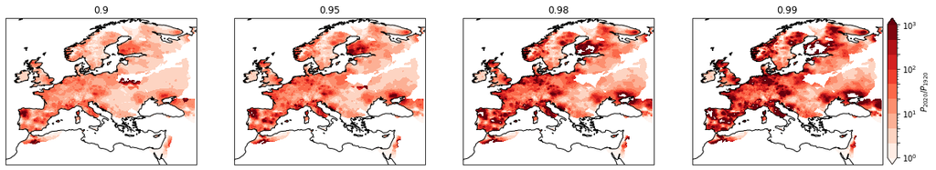

```python
fig,ax=plt.subplots(1,4,figsize=(20,8),subplot_kw=dict(projection=crs.PlateCarree()))

c=[ax.flatten()[i].contourf(p_2020.longitude,p_2020.latitude,(p_2020 / p_1920).sel(quantile=quantile),levels=[1,2,5,10,20,50,100,200,500,1000],extend='both',norm=matplotlib.colors.LogNorm(1,1000),cmap='Reds') for i,quantile in enumerate(p_2020['quantile'])]

axins = inset_axes(ax[-1], width="5%",height="100%",loc='lower left',bbox_to_anchor=(1.025, 0.00, 1, 1),bbox_transform=ax[-1].transAxes,borderpad=0)
cbar = plt.colorbar(c[-1],cax=axins,)
cbar.set_label('$P_{2020}/P_{1920}$',labelpad=3)

[a.coastlines() for a in ax.flatten()]
[ax[i].set_title(x) for i,x in enumerate(p_2020['quantile'].values)]
''
```

## III. A more careful analysis: bootstrapping

The analysis above was fairly broad-brush (best-estimate only, not very careful about masked data etc.). In this final example, I demonstrate what I think is one of the key abilities of this package: rapid bootstrapped estimates.

Since both the `OLSE` and `LMoments` packages use numpy under the hood, they broadcast as expected. This means that retaining bootstrap sample correspondence is straightforward.

Here, I'll be focusing on the Oxford gridpoint data.

```python
y_raw = txx_eobs.sel(latitude=51.75,longitude=-1.25,method='nearest').values
x_raw = GMST.loc[txx_eobs['time.year'].values,'smooth'].values
```

```python
## resample with replacement over these series using numpy fancy indexing:
N_boot = 10000
indices = np.random.choice(y_raw.size,y_raw.size*N_boot)

Y = y_raw[indices].reshape(y_raw.size,-1)
X = x_raw[indices].reshape(x_raw.size,-1)
```

```python
## simple linear regression (no masked values this time!):
SLR_boot = OLSE.simple(Y)
SLR_boot.fit(X)
```

```python
## fit GEV
GEV_boot = LMoments.gev()
GEV_boot.fit(SLR_boot.res)
```

```python
## set the location parameter equal to the 1961-1990 model mean
### Note that the input data must be type numpy array (ie. not masked arrays etc.) or you may get weird results...
GEV_boot.X = SLR_boot.pred(GMST.loc['1961':'1990','smooth'].mean()).data
```

```python
## now obtain present-day & 1920 GEV estimates by shifting the (bootstrapped) distribution locations:
GEV_boot_2020 = copy.deepcopy(GEV_boot)
GEV_boot_2020.X = SLR_boot.pred(GMST.loc[2020,'smooth']).data

GEV_boot_1920 = copy.deepcopy(GEV_boot)
GEV_boot_1920.X = SLR_boot.pred(GMST.loc[1920,'smooth']).data
```

```python
## here I'll focus on the 1-in-50 year events only
p_boot_2020 = 1-GEV_boot_2020.cdf(GEV_boot.qf(0.98))
p_boot_1920 = 1-GEV_boot_1920.cdf(GEV_boot.qf(0.98))
```

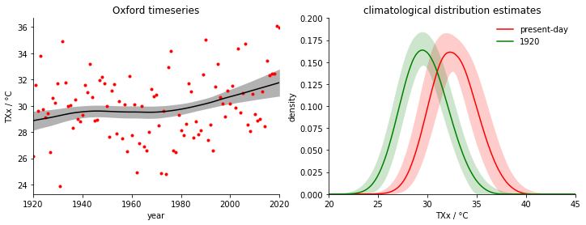

```python
# create a plot of all the distributions
fig,ax = plt.subplots(1,2,figsize=(12,4))

## timeseries plot
ax[0].plot(txx_eobs['time.year'].values,y_raw,'r.',label='E-OBS')
ax[0].plot(txx_eobs['time.year'].values,np.median(SLR_boot.pred(x_raw[:,None]),axis=1),'k',label='best-estimate')
ax[0].fill_between(txx_eobs['time.year'].values,*np.quantile(SLR_boot.pred(x_raw[:,None]),[0.05,0.95],axis=1),color='k',alpha=0.3,lw=0,label='90% CI')
ax[0].set_xlim(1920,2020)
ax[0].set_xlabel('year')
ax[0].set_ylabel('TXx / \N{DEGREE SIGN}C')
ax[0].set_title('Oxford timeseries')

## distribution plot
xrange=np.arange(20,50,0.1)
ax[1].plot(xrange,np.median(GEV_boot_2020.pdf(xrange[:,None]),axis=1),color='r',label='present-day')
ax[1].fill_between(xrange,*np.quantile(GEV_boot_2020.pdf(xrange[:,None]),[0.05,0.95],axis=1),color='r',alpha=0.2,lw=0)
ax[1].plot(xrange,np.median(GEV_boot_1920.pdf(xrange[:,None]),axis=1),color='g',label='1920')
ax[1].fill_between(xrange,*np.quantile(GEV_boot_1920.pdf(xrange[:,None]),[0.05,0.95],axis=1),color='g',alpha=0.2,lw=0)

ax[1].legend(frameon=False)
ax[1].set_xlabel('TXx / \N{DEGREE SIGN}C')
ax[1].set_ylabel('density')
ax[1].set_ylim(0,0.2)
ax[1].set_xlim(20,45)
ax[1].set_title('climatological distribution estimates')

sn.despine()
```

```python
## finally print out some risk ratios + confidence for a 1-in-50 year event

print('1-in-50 year event RR [90 % CI]:',round(np.median(p_boot_2020/p_boot_1920),2),np.round(np.quantile(p_boot_2020/p_boot_1920,[0.05,0.95]),2),'\n')

print('1-in-50 year event FAR [90 % CI]:',round(np.median(1-p_boot_1920/p_boot_2020),2),np.round(np.quantile(1-p_boot_1920/p_boot_2020,[0.05,0.95]),2))
```

```
1-in-50 year event RR [90 % CI]: 18.17 [  3.81 260.84]

1-in-50 year event FAR [90 % CI]: 0.94 [0.74 1.  ]
```

#### A final note

Statistically speaking, for this type of analysis it would be optimal to fit a model using MLE (ie. assuming an explicit trend + GEV error model). This package cannot be used to achieve this. However, I find that it can be useful to separate out the two components (ie. fit the trend and distribution separately). This package can help with this. In addition, it is considerably faster than using currently available scipy `.linregress()` and `.fit()` methods due to the vectorisation.